# R Notebook

### Testing methods of removing originals

```r
# extracting just the significant ones (i.e., successful replications according to p < .05 on the replication)
```

| Included Articles | Mean proportion change | Mean replication ES | Mean original studies ES | Mean ES difference | SD difference | Median proportion change | Median replicaiton ES | Median original ES | Median difference | n included | n criteria calculable for | 95% CI LB Mean ES Change | 95% CI UB Mean ES Change | Number included in model | Estimated decrease model | 95% CI LB Mean ES change model | 95% CI UB Mean ES change model |
| --- | --- | --- | --- | --- | --- | --- | --- | --- | --- | --- | --- | --- | --- | --- | --- | --- | --- |
| Overall | -0.29 | 0.28 | 0.40 | -0.13 | 0.26 | -0.35 | 0.21 | 0.34 | -0.11 | 314 | 314 | -0.16 | -0.10 | 305 | -0.14 | -0.21 | -0.07 |
| StatisticalSignificance | 0.03 | 0.40 | 0.43 | -0.02 | 0.20 | -0.07 | 0.34 | 0.37 | -0.04 | 220 | 314 | -0.05 | 0.00 | 195 | -0.05 | -0.12 | 0.01 |
| Nonequivalence | -0.07 | 0.36 | 0.43 | -0.07 | 0.24 | -0.16 | 0.31 | 0.36 | -0.06 | 237 | 305 | -0.10 | -0.04 | 235 | -0.08 | -0.16 | -0.01 |
| BF0RepBelow3 | -0.15 | 0.35 | 0.43 | -0.07 | 0.18 | -0.23 | 0.29 | 0.34 | -0.08 | 160 | 243 | -0.10 | -0.05 | 160 | -0.09 | -0.15 | -0.03 |
| BFRep0Above3 | -0.04 | 0.41 | 0.45 | -0.04 | 0.18 | -0.11 | 0.33 | 0.36 | -0.04 | 126 | 243 | -0.07 | -0.01 | 126 | -0.07 | -0.13 | 0.00 |
| BF01Below3 | -0.04 | 0.38 | 0.45 | -0.06 | 0.26 | -0.13 | 0.33 | 0.37 | -0.05 | 219 | 304 | -0.10 | -0.03 | 217 | -0.09 | -0.16 | -0.01 |
| BF10Above3 | 0.08 | 0.42 | 0.44 | -0.01 | 0.21 | -0.04 | 0.37 | 0.37 | -0.01 | 175 | 304 | -0.05 | 0.02 | 173 | -0.05 | -0.11 | 0.02 |
| BF0PBelow3 | -0.04 | 0.37 | 0.44 | -0.07 | 0.25 | -0.14 | 0.32 | 0.37 | -0.05 | 230 | 304 | -0.10 | -0.03 | 228 | -0.09 | -0.16 | -0.02 |
| BFP0Above3 | 0.08 | 0.42 | 0.44 | -0.01 | 0.21 | -0.05 | 0.37 | 0.37 | -0.01 | 184 | 304 | -0.04 | 0.02 | 182 | -0.05 | -0.11 | 0.02 |

TOST - Exclude inconclusive ones -

Bayesian modelling - compare data for and against

## https://osf.io/z7aux/

NOTE ! ! ! - it may be important to use dis-attenuated values from LOOPR because they used short form analyses

## Supplementary material

#### Table [BayesFactors]

One-sided and ($BF_{plus1}$) and replication ($BF_{rep1}$) Bayes Factors for as reported in {Camerer, 2018 #967} and as estimated in the current paper, along with the reported correlation coefficients and sample sizes from the original and replicaiton studies.

| Article | Original_r | Original_N | Replication_r | Replication_n | Camerer_et_al._BFP0 | Camerer_et_al._BFRep0 | BFrep0 | BF0plus | BF01 |
| --- | --- | --- | --- | --- | --- | --- | --- | --- | --- |
| Ackerman et al. (2010), Science | 0.27 | 54 | 0.09 | 858 | 5.4000e-01 | 0.31 | 2.65 | 2.06 | 1.04 |
| Aviezer et al. (2012), Science | 0.96 | 15 | 0.83 | 14 | 4.4600e+02 | 57.00 | 226.82 | 274.00 | 137.04 |
| Balafoutas and Sutter (2012), Science | 0.28 | 72 | 0.15 | 243 | 4.2000e+00 | 4.27 | 4.12 | 2.12 | 1.07 |
| Derex et al. (2013), Nature | 0.52 | 51 | 0.36 | 65 | 3.1440e+03 | 3701.00 | 33.42 | 21.78 | 10.91 |
| Duncan et al. (2012), Science | 0.67 | 15 | 0.37 | 128 | 2.6820e+03 | 2513.00 | 2047.92 | 2335.00 | 1167.51 |
| Gervais and Norenzayan (2012), Science | 0.29 | 57 | -0.04 | 755 | 6.0000e-02 | 0.03 | 0.03 | 0.02 | 0.09 |
| Gneezy et al. (2014), Science | 0.22 | 178 | 0.18 | 407 | 2.3190e+02 | 485.27 | 472.06 | 113.00 | 56.51 |
| Hauser et al. (2014), Nature | 0.82 | 40 | 0.83 | 22 | 2.8890e+03 | 10211.00 | 101945.01 | 24633.95 | 12317.00 |
| Janssen et al. (2010), Science | 0.63 | 63 | 0.34 | 42 | 5.8600e+00 | 0.00 | 1.90 | 4.18 | 2.12 |
| Karpicke and Blunt (2011), Science | 0.60 | 40 | 0.38 | 49 | 1.4550e+01 | 11.82 | 13.99 | 13.05 | 6.55 |
| Kidd and Castano (2013), Science | 0.27 | 86 | -0.04 | 999 | 5.0000e-02 | 0.01 | 0.01 | 0.02 | 0.08 |
| Kovacs et al. (2010), Science | 0.45 | 24 | 0.59 | 95 | 5.5700e+07 | 132389304.00 | 86776199.93 | 54424990.81 | 27212495.42 |
| Lee and Schwarz (2010), Science | 0.39 | 40 | -0.05 | 409 | 8.0000e-02 | 0.01 | 0.02 | 0.03 | 0.11 |
| Morewedge et al. (2010), Science | 0.45 | 32 | 0.35 | 89 | 8.6870e+01 | 157.85 | 164.64 | 80.78 | 40.41 |
| Nishi et al. (2015), Nature | 0.20 | 200 | 0.12 | 480 | 7.0500e+00 | 7.77 | 8.39 | 2.87 | 1.44 |
| Pyc and Rawson (2010), Science | 0.38 | 36 | 0.15 | 438 | 6.8300e+00 | 4.04 | 16.79 | 15.99 | 8.00 |
| Ramirez and Beilock (2011), Science | 0.79 | 20 | -0.09 | 105 | 1.4000e-01 | 0.00 | 0.00 | 0.07 | 0.19 |
| Rand et al. (2012), Nature | 0.14 | 343 | 0.03 | 3150 | 1.4000e-01 | 0.10 | 0.13 | 0.13 | 0.07 |
| Shah et al. (2012), Science | 0.27 | 56 | -0.04 | 897 | 7.0000e-02 | 0.04 | 0.04 | 0.02 | 0.08 |
| Sparrow et al. (2011), Science | 0.37 | 69 | 0.07 | 338 | 1.5000e-01 | 0.03 | 0.06 | 0.26 | 0.15 |
| Wilson et al. (2014), Science, | 0.67 | 30 | 0.59 | 39 | 6.0125e+02 | 1871.00 | 1926.34 | 830.41 | 415.22 |

### Plots of the relationship between original and replication correlation coefficents, removing different sets of possibly null results

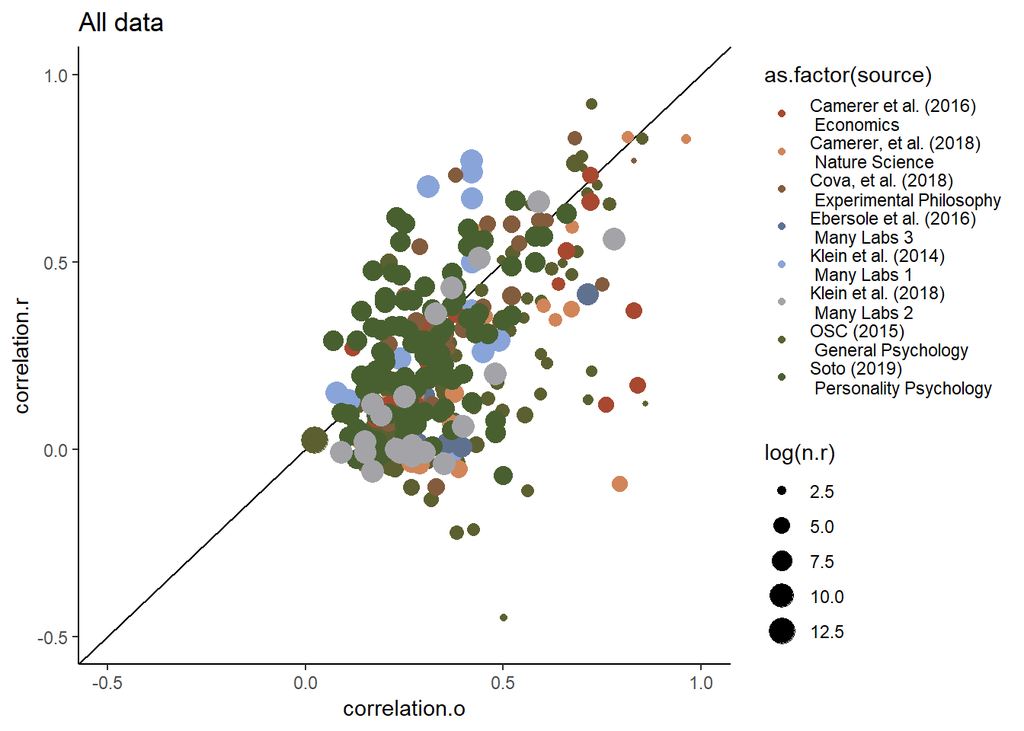

```r
plotAllData
```

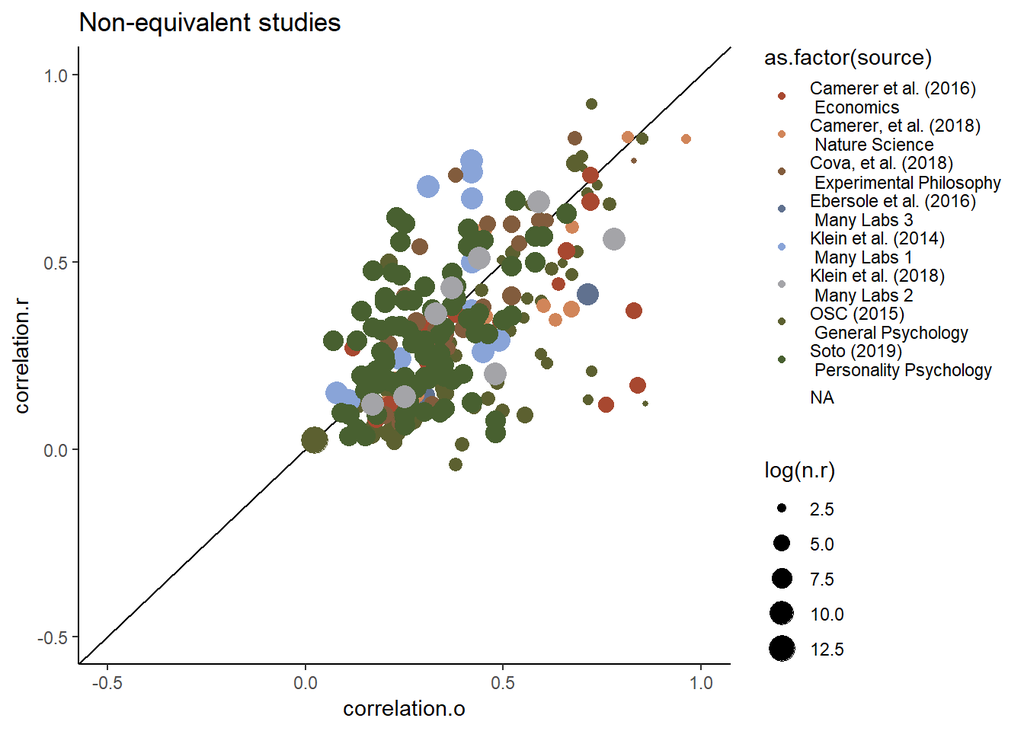

```r
plotNonequiv
```

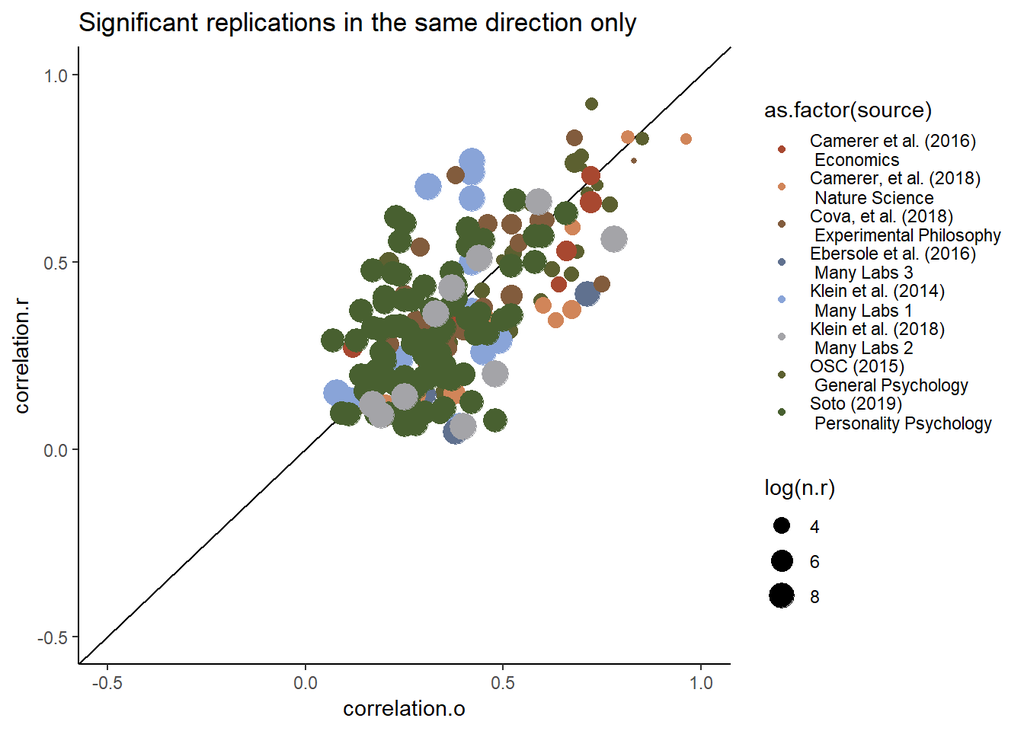

```r
plotSigR
```

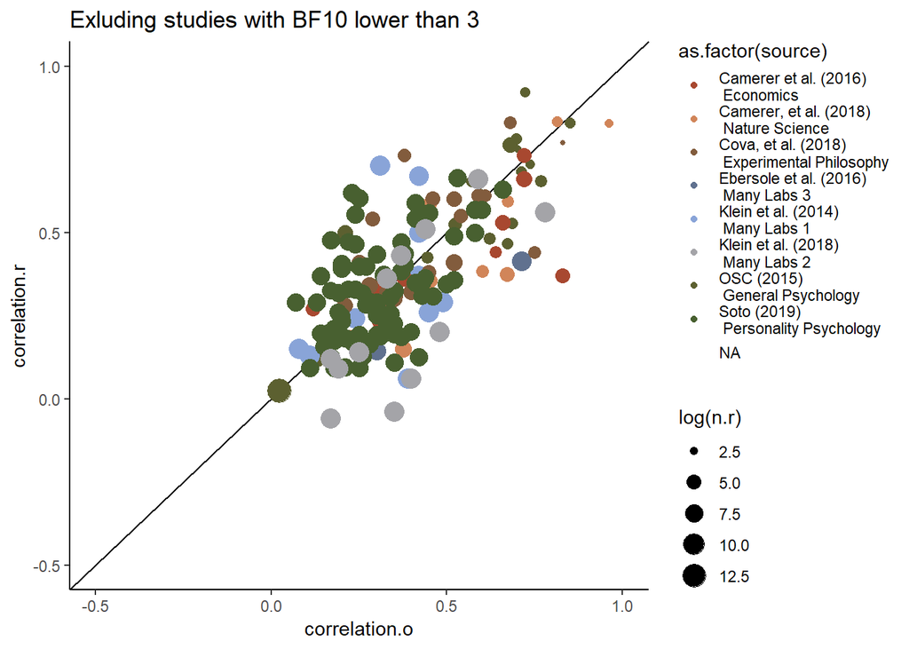

```r
plotBF10Greater3
```

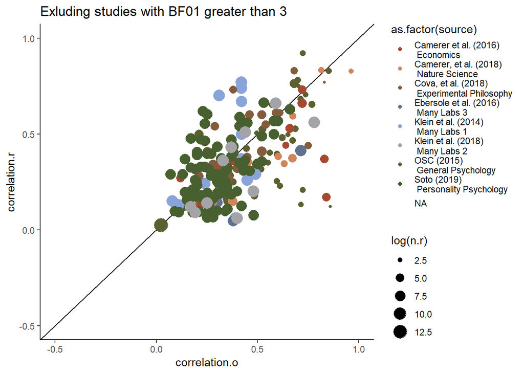

```r
plotBF01Lesser3
```

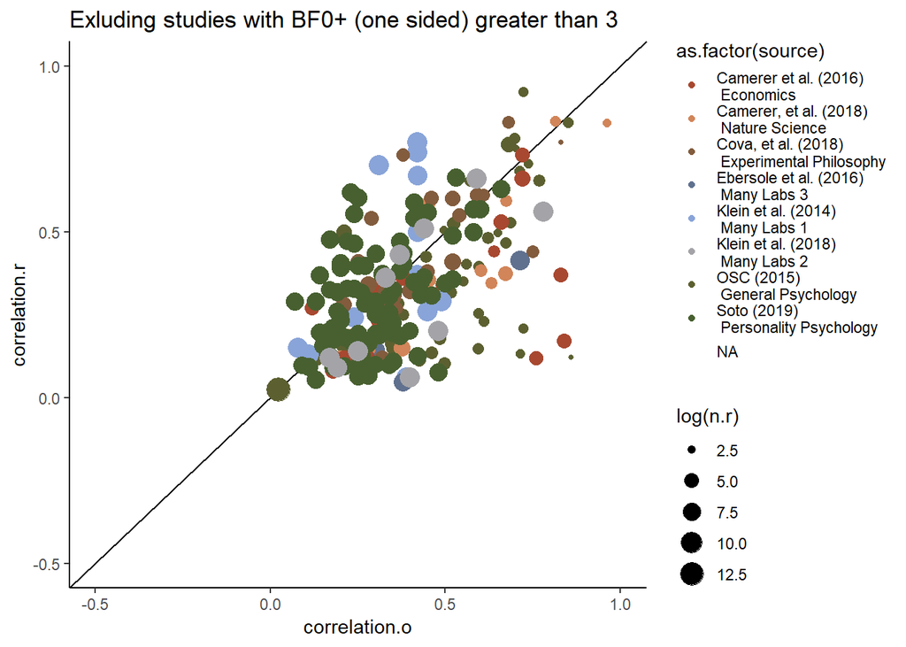

```r
plotBF0plusLesser3
```

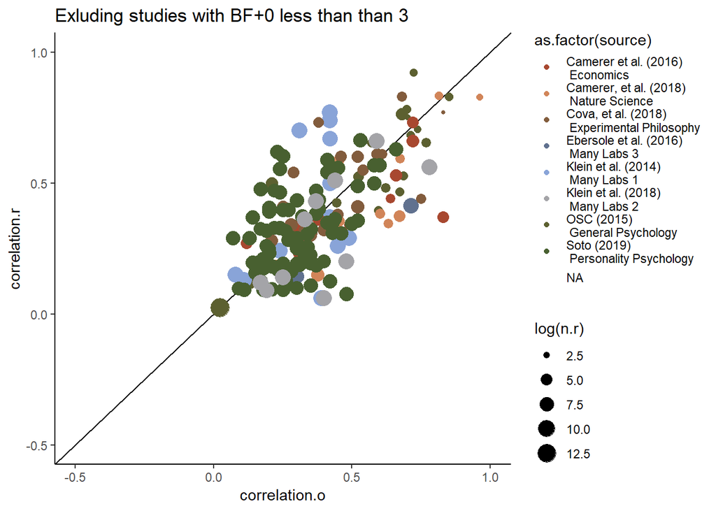

```r
plotBFPlus0Greater3
```

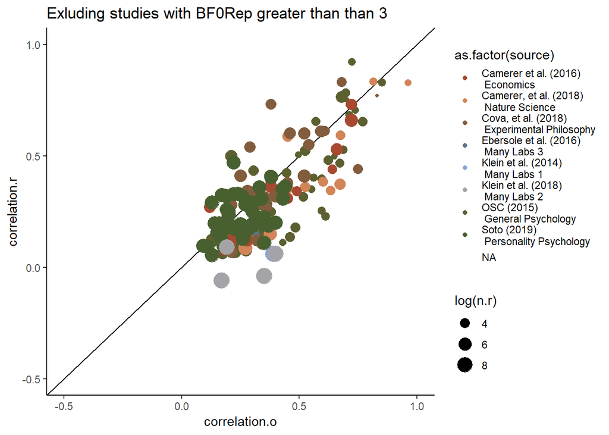

```r
plotBFRep0Lesser3
```